# Paying for Tomorrow’s Health Care

John A. Graves, Ph.D.

Professor of Health Policy and Medicine, Vanderbilt School of Medicine

Professor of Management, Owen Graduate School of Management

2026-05-01

## Disclosures

| Relationship | Entity |
| --- | --- |
| Spouse — Employment | Aledade, Inc. (a primary care accountable care organization) |
| Other commercial interests | **None** |

The content of this presentation reflects the speaker’s independent academic analysis. No commercial entity has reviewed, edited, or approved any portion of the material.

# Part 1: The Chassis

The same payment architecture runs through every U.S. health-care dollar.

A high-income country pays outpatient physicians **fee-for-service** off a national fee schedule.

Hospitals are paid **per case via DRGs**.

**Private insurers** compete for patients.

Which country?

## It’s Germany — same chassis, very different cost

Outpatient is FFS off the **EBM** schedule.

Inpatient via **G-DRGs**.

**~$9,400** per capita

vs.

**~$13,500** in the U.S.

The chassis is the same. The structures *around* the chassis are not.

Source: OECD Health at a Glance, 2023.

EBM = *Einheitlicher Bewertungsmaßstab* (Uniform Value Scale) — Germany’s national outpatient fee schedule

## US vs. Germany

|  | U.S. | Germany |
| --- | --- | --- |
| **Risk pooling** | Fragmented | Universal via ~95 sickness funds |
| **Benefits package** | Vary by plan, employer, year | Single nationally defined package |
| **Payment rates** | Bilaterally negotiated | Collectively negotiated; applied uniformly |
| **Aggregate spending control** | None | Regional outpatient budgets; KHVVG hospital reform (2025) |

## One in three U.S. health-care dollars is administrative

$2,500

per capita on admin in the U.S.

$550

per capita in Canada

Per-physician admin cost is **~4× higher** than Canada’s.

Practice spending on prior-auth staffing rose **43%** from 2019 to 2024.

Sources: Cutler, Brookings (2020); Himmelstein, Campbell, Woolhandler, *Annals of Internal Medicine* (2020); MGMA (2024).

## FFS rewards volume — but volume isn’t where U.S. cost comes from

|  | U.S. | Germany | OECD avg. |
| --- | --- | --- | --- |
| Doctor visits / capita | 4.0 | **9.9** | 6.8 |
| Hospital beds / 1,000 | 2.8 | **7.8** | 4.3 |
| Average length of stay (days) | 5.4 | **8.9** | 6.7 |

The FFS volume incentive is real. Germany has it too.

Sources: OECD Health Statistics; Anderson, Reinhardt et al., *Health Affairs* (2003).

## Medicare prices ~10,000 services with one formula

Payment = Work + Practice Expense + Malpractice × Conversion Factor

Relative Value Units (RVUs)

## Total spending is payment (P) times quantity (Q)

[video not shown]

## Commercial contracts don’t negotiate thousands of prices — they negotiate multipliers

Medicare Payment = RVUs × **$33.89**

Commercial Payment = RVUs × **$33.89 × 1.8**

**~75%** of all commercial services are directly benchmarked to Medicare’s relative values.

Contracts often use **tiered multipliers** by service type — e.g., E/M at 130%, procedures at 170% of Medicare.

Source: Clemens & Gottlieb, “In the Shadow of a Giant: Medicare’s Influence on Private Physician Payments,” *Journal of Political Economy* 125(1), 2017.

E/M = evaluation and management (office visits, consultations)

## The chassis isn’t just scaffolding — it’s a sounding board

Because ~75% of commercial contracts are pegged to Medicare, any change Medicare makes **amplifies and reverberates through the entire health-care economy**.

A **$1** change in the Medicare fee schedule

becomes a **$1.16** change in private payments.

Medicare serves as a **reference system** that commercial market negotiations orbit around.

Source: Clemens & Gottlieb, “In the Shadow of a Giant,” *Journal of Political Economy* (2017).

## A $1 Medicare cut becomes a $1.16 private cut

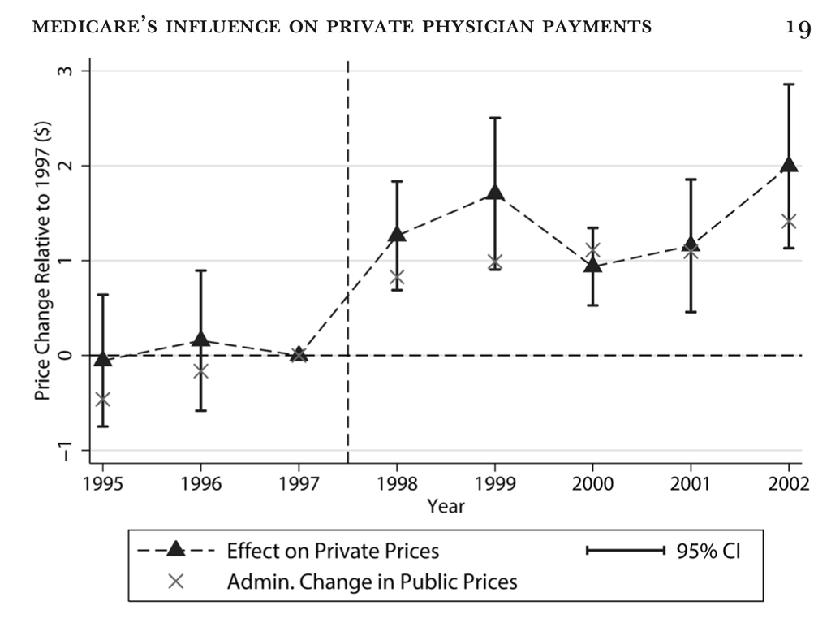

Source: Clemens & Gottlieb, “In the Shadow of a Giant,” *Journal of Political Economy* (2017).

## Commercial pays well above Medicare — varying by service type

| Service type | Commercial as % of Medicare |
| --- | --- |
| Hospital services (combined) | **223%** |
| Hospital outpatient | 240% |
| Hospital inpatient | 182% |
| Physician services | 129% |

Source: Congressional Budget Office (2022).

## Consolidation pushes the multiplier up

**1,331** hospital mergers since 2000

**69%** of hospitals now in systems

Physician employment: **28% → 47%** (2008–2016)

CBO: **zero association** between commercial prices and quality.

Source: Gaynor, “Three Points About Consolidation in Health Care Markets” (2025); CBO (2022).

# Part 2: What We’ve Learned

Patient cost-sharing provides **volume control**, not **value control**.

## Patient cost-sharing provides volume control, not value control

The standard response to rising costs: make consumers pay more, and they’ll shop smarter.

HDHP enrollment surged from **13% to 33%** of the privately insured population (2010–2025). Utilization dropped **~15%**.

But researchers studied what actually happens when a large employer switched to a high-deductible plan:

- Spending fell **immediately** — but patients cut **all** care indiscriminately
- They did not price-shop. They did not distinguish necessary from unnecessary care
- The savings came almost entirely from **avoiding care**, not from finding better prices
- Low-income employees reduced spending the most — including **high-value preventive care**

Source: Brot-Goldberg et al., “What Does a Deductible Do?”, *Quarterly Journal of Economics* (2017).

HDHP = high-deductible health plan

## And when patients can’t pay, providers absorb the bill

Cost-sharing has a second-order effect: a large share never gets collected.

- Hospital **bad debt** ran **~$42B** in 2023 — and roughly **half** is now from *insured* patients who can’t meet their deductible
- Uncompensated care has climbed in lockstep with HDHP enrollment

Unpaid cost-sharing is, in effect, an **implicit tax on providers** — shifting the financing burden from payer to provider, off-budget.

Mark Cuban: high deductibles turn providers into **unwitting subprime lenders** — they bear **100% of the credit risk** for unpaid copays and deductibles.

What about just **showing consumers the prices**?

## What about just showing consumers the prices?

Since 2021, hospitals must publish negotiated prices for every service. Since 2023, insurers must offer online price comparison tools.

But **only 9%** of Americans even know the data exists. When California offered state employees a transparency tool, **only 12%** used it.

And when patients *do* have prices, it doesn’t matter much. Patients bypass an average of **6 cheaper MRI providers** on the way to their appointment — because their doctor told them where to go.

Physician referral explains **52×** more price variance than patient cost-sharing.

Sources: KFF Health Tracking Poll; Desai et al., *Health Affairs* (2017); Chernew, Cooper et al., *Journal of Health Economics* (2021).

## When you publish prices, suppliers pay attention

In 1993, Denmark published firm-specific prices for concrete to promote competition. Within a year, prices **rose 15–20%**. Transparency eliminated secret discounting and made it easier for firms to coordinate upward.

The same pattern is emerging in healthcare. A randomized trial of New York’s price transparency tool found that billed charges **increased 0.75%** — driven by low-priced providers raising prices once they could see what competitors charged.

The primary users of hospital pricing data are **not patients** — they are hospitals and insurers using it as competitive intelligence.

Sources: Albæk et al., *Journal of Industrial Economics* (1997); Barnes, Glied et al., NBER Working Paper 32580 (2024); KFF Health News (2026).

## Transparency works when it changes the choice architecture, not just the information set

CalPERS (California Public Employees’ Retirement System) set a **reference price** of $30,000 for hip and knee replacements. Choose a facility at or below that price — no extra cost. Choose above it — you pay the difference.

- Average price per procedure fell **26%**. CalPERS saved **$5.5 million** in two years.
- **85%** of savings came from hospitals **cutting their prices** to stay under the cap — not from patients switching.
- Same approach for colonoscopy ($1,500 cap): prices fell **21%**, ambulatory surgery center use rose from 69% to 91%.

The lesson: **don’t ask patients to shop — change the default.** Make the high-value option the path of least resistance, and let providers compete to be on it.

Sources: Robinson & Brown, *Health Affairs* (2017); Whaley, *American Journal of Health Economics* (2019); Robinson et al. (2021).

## The scalpel exists: align the price tag with clinical value

**Value-based insurance design (V-BID):** instead of charging the same copay for everything, make high-value care cheap and low-value care expensive. Let the price tag encode the clinical evidence.

The MI FREEE trial (Choudhry et al., *NEJM* 2011): heart attack survivors randomized to **$0 copay** for statins, beta-blockers, and ACE inhibitors.

- Medication adherence **increased 4–6 percentage points**
- Patient out-of-pocket costs fell **~$264/year**
- Total healthcare spending **did not increase** — free drugs were offset by fewer hospitalizations

Traditional cost-sharing asks patients to be their own doctor.

V-BID admits they can’t be — and uses the price tag to tell them which drugs and care actually matter.

Source: Choudhry et al., “Full Coverage for Preventive Medications after Myocardial Infarction,” *NEJM* (2011).

Is **value-based care** the offramp from FFS?

## What does `value` mean in healthcare?

Value = $\dfrac{\text{Risk adjusted outcomes}}{\text{Total Cost}\quad (P \times Q)}$

FFS maximizes the **denominator**. Every service adds cost, regardless of whether it improves the outcome.

Value-based care (VBC) attempts to **flip the incentive** — reward the numerator, constrain the denominator.

## The value chain: how VBC is supposed to work

[figure not shown]

Source: Jordan Anderson, MD, MBA, Belong Health.

## Most “value-based” models are still bolted onto the FFS chassis

| Model | How it works | Still on the chassis? |
| --- | --- | --- |
| **Pay for performance** | FFS + bonus/penalty for hitting quality targets | Yes — FFS is the base payment |
| **Bundled / episode payment** | Single price for an episode (e.g., hip replacement, 90 days). Typically, FFS payment + reconciliation against a target | Mostly — bundle price derived from historical FFS spending |
| **Shared savings (ACOs)** | FFS payment + reconciliation against a spending benchmark | Yes — benchmark set from FFS claims history |
| **Shared risk (ACOs)** | Same, but provider owes money if spending exceeds benchmark | Yes — same FFS-derived benchmark |
| **Global payment** | Fixed $/patient/month — provider bears full risk | **No** — fully off the chassis |

Each model adds a layer of accountability — but only global payment changes the **underlying price architecture**.

ACO = accountable care organization

## Where are we? Mostly still on the FFS interstate

|  | All payers | Medicare | Medicare Advantage | Commercial |
| --- | --- | --- | --- | --- |
| **FFS or FFS + quality bonus** | ~55% | ~56% | ~36% | ~61% |
| **Shared savings/risk (ACOs, bundles)** | ~35% | ~34% | ~43% | ~31% |
| **Global / capitated** | ~10% | ~10% | ~21% | ~8% |

**511** ACOs now participate in Medicare’s Shared Savings Program, covering **12.6 million** beneficiaries — **53%** of traditional Medicare.

CMS’s stated goal: every Medicare FFS beneficiary in an accountable care relationship by **2030**.

Sources: HCP-LAN / AHIP APM Measurement (CY 2024); CMS MSSP Participation Highlights (2026).

# Extra Slides

## Lately, the volume engine is revving harder

U.S. health spending hit **$5.3 trillion** in 2024 — up **7.2%**. But healthcare prices grew only **2.5%**, *below* general inflation.

The rest? **Volume and intensity** — more encounters, higher-acuity coding, new high-cost drugs, site-of-service shifts to hospital outpatient departments.

Sources: CMS National Health Expenditure Data (2024); Chernew, “It’s Not the Prices, Stupid,” *Health Affairs Forefront* (2026); Hartman et al., *Health Affairs* (2026).

## Some of the growth is real — more people getting more care

**GLP-1 drugs** — U.S. GLP-1 spending: **$13.7B** (2018) → **$71.7B** (2023). ~6–7 million Americans now on a GLP-1. List prices run **$1,000–$1,350/month**. Medicare-negotiated prices (~$245/month, effective 2026–2027) will lower per-unit cost but likely expand volume further.

**Behavioral health** — Utilization up **~40%** vs. pre-pandemic. Telehealth removed access barriers, and unmet demand is being met. Growing **12–15% annually** — a permanent reset, not a post-COVID blip.

**Demographics** — **11,000 Americans/day** aging into Medicare. The oldest, sickest, most expensive cohort in history is just entering the system. This will persist for decades.

Sources: CMS National Health Expenditure Projections (2024); Evernorth/Cigna Behavioral Health Trends (2025).

## But some of what looks like “volume” is really intensity in disguise

**Site-of-service shifts** — When hospitals acquire physician practices, care moves from offices to hospital outpatient departments at higher prices. MedPAC: HOPD spending growing **~2 pp faster** than office-based spending annually. This is the **consolidation** story, once again.

**AI coding intensity** — Ambient AI scribes are increasing documented diagnoses per encounter (3.0 → 4.1 at Texas Oncology) and wRVUs (+11% at Riverside Health). Same encounters, more revenue. This is the **FFS documentation** machine on steroids.

Sources: MedPAC Report to Congress (2024); *Nature Digital Medicine* (2025).